# Final project

Yuet Shan LO

2025-05-07

# Declarition

This document involved the use of genAI for comment, and some of the figure debugging with some graphics formatting, and improvement of the grammar.

# Background:

The data is used to predict the age of the abalone base on the length, Sex, Diameter,Height, Whole weight, Shrucked weight,Viscera weight and shell weight. The **target variable** is *rings.* The *Rings* target is showing the age +1.5, which is an integer. Other variables, expect **sex**, is contentious variable that are really suitable to predict the value using regression method.

## The number of variables:

There is 4177 instances, with 8 feature and 1 target, at total is :
$$4177 \times 9 = 37593
\ \text{variables}$$

## The method that retains the age of the abalone (rings):

According to the introduction of dataset,refer to the abalone.name files

> *“The age of abalone is determined by cutting the shell through the cone, staining it, and counting the number of rings through a microscope”*

That means the dataset are handled in lab

## Handling method of the missing value:

According to the introduction of dataset, refer to the abalone.name files

> *“From the original data examples with missing values were removed (the majority having the predicted value missing).”*

That mean that they simply clear all the missing data

# License & citations

This dataset is licensed under the [Creative Commons Attribution 4.0 International (CC BY 4.0) license.](https://creativecommons.org/licenses/by/4.0/).

## Explanation of the License:

The license can be used for all usage, including sharing,and adapt the usage freely, even using as a profit measure. However, using the dataset need to be cited and credit to the author.

# Dataset

```r
# import library
library(tidyverse)
# setup the colomn names
colomns_names <- c("Sex", "Length", "Diameter", "Height", "Whole_weight", "Shucked_weight", "Viscera_weight", "Shell_weight", "Rings")

colomns_names
```

```
## [1] "Sex"            "Length"         "Diameter"       "Height"
## [5] "Whole_weight"   "Shucked_weight" "Viscera_weight" "Shell_weight"
## [9] "Rings"
```

```r
d <- read.csv('abalone.data',sep = ","
                 ,header = FALSE,
                 col.names = colomns_names,
                 na.strings = c(""," ","NA"))



## drop nan colomns
d <- d %>% drop_na()
```

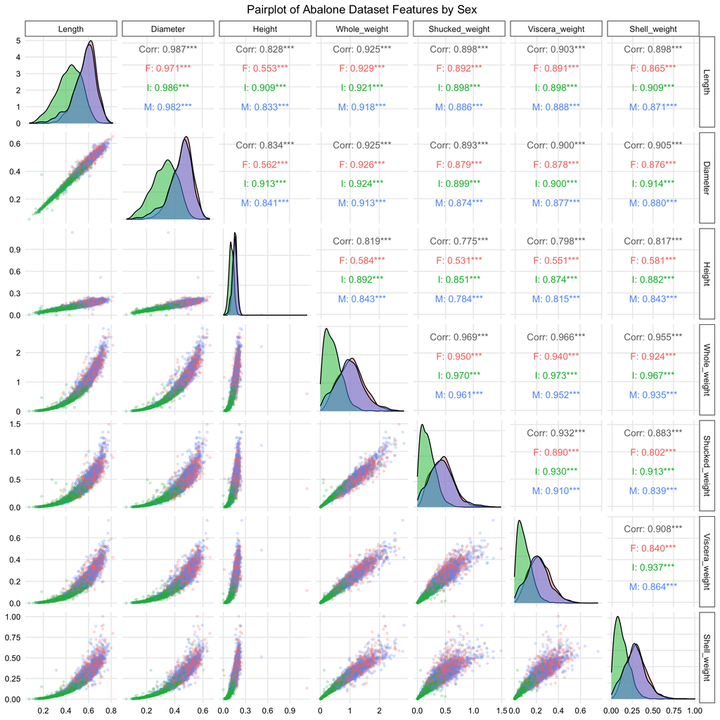

```r
# Load required libraries for plotting
library(GGally)    # For ggpairs (pairplot functionality)
library(ggplot2)   # Core plotting library for theme customization

# Define features to include in the pairplot
features <- c("Length", "Diameter", "Height", "Whole_weight",
              "Shucked_weight", "Viscera_weight", "Shell_weight")

# Create pairplot with scatter plots (lower) and correlations (upper)
g1 <- ggpairs(
  data = d,
  columns = which(names(d) %in% features),  # Select feature columns
  aes(colour = Sex, alpha = 0.5),           # Color by Sex, set transparency
  lower = list(continuous = wrap("points", size = 1, alpha = 0.2)),  # Scatter plots
  upper = list(continuous = wrap("cor", size = 4, method = "pearson")), # Correlations
  diag = list(continuous = wrap("densityDiag", alpha = 0.5)),  # Density plots on diagonal
  title = "Pairplot of Abalone Dataset Features by Sex",
  axisLabels = "show"  # Show axis labels
) +
  # Apply a clean, minimal theme with scientific styling
  theme_minimal(base_size = 12) +
  theme(
    plot.title = element_text(hjust = 0.5, face = "plain", size = 14), # Centered, plain title
    axis.text = element_text(color = "black"),  # Black axis text for contrast
    strip.text = element_text(face = "plain", size = 10), # Simple, plain facet labels
    strip.background = element_rect(fill = "white", color = "black"), # Plain facet background
    panel.grid.minor = element_blank()  # Remove minor grid lines for clarity
  )

# Display the pairplot
g1
```

# Box and Sina plot

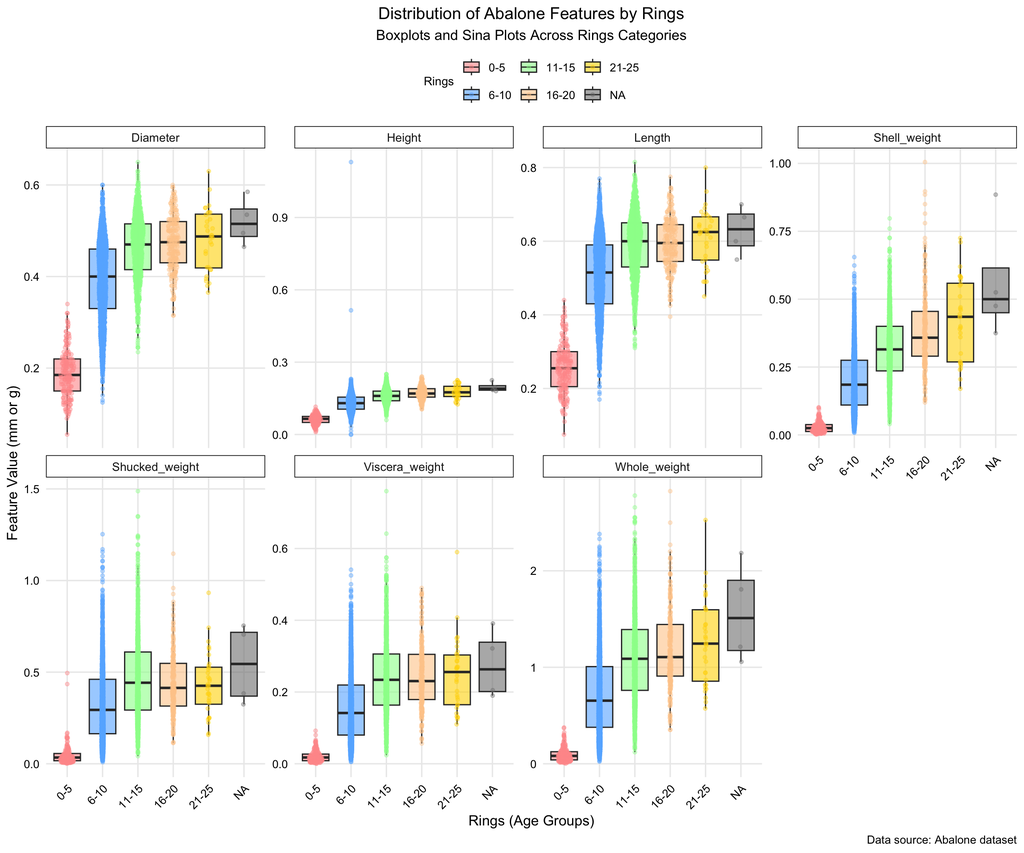

```r
# Load required libraries for plotting and data manipulation
library(ggplot2)      # Core plotting library for visualizations
library(ggforce)      # For geom_sina (sina plots)
library(tidyr)        # For pivot_longer to reshape data

# =============================================
# DATA PREPARATION
# =============================================

# Define features to plot (Abalone measurements)
features <- c("Length", "Diameter", "Height", "Whole_weight",
              "Shucked_weight", "Viscera_weight", "Shell_weight")

# Create a numeric copy of Rings and categorize Rings into 5 groups
d$Rings_numeric <- d$Rings  # Preserve original Rings as numeric
d$Rings <- cut(
  d$Rings,
  breaks = c(0, 5, 10, 15, 20, 25),
  labels = c("0-5", "6-10", "11-15", "16-20", "21-25"),
  include.lowest = TRUE  # Ensure lowest value is included in first bin
)

# Reshape data to long format for faceting by feature
d_long <- d %>%
  pivot_longer(
    cols = all_of(features),
    names_to = "Feature",
    values_to = "Value"
  )

# =============================================
# VISUALIZATION
# =============================================

# Create faceted boxplot and sina plot
ggplot(data = d_long, aes(x = Rings, y = Value)) +
  # Add boxplots, colored by Rings, hiding outliers (handled by sina)
  geom_boxplot(
    aes(fill = Rings),
    outlier.shape = NA,
    alpha = 0.6  # Light transparency for layering
  ) +
  # Add sina plot for individual points, colored by Rings
  geom_sina(
    aes(colour = Rings),
    size = 1.2,       # Moderate point size for visibility
    alpha = 0.4,      # Transparency to handle overlap
    maxwidth = 0.4    # Fit points within boxplot boundaries
  ) +
  # Customize fill colors for boxplots
  scale_fill_manual(
    values = c("#FF9999", "#66B3FF", "#99FF99", "#FFCC99", "#FFD700"),
    name = "Rings"    # Legend title
  ) +
  # Customize point colors for sina plots
  scale_colour_manual(
    values = c("#FF9999", "#66B3FF", "#99FF99", "#FFCC99", "#FFD700"),
    name = "Rings"    # Legend title
  ) +
  # Facet by Feature with free y-scales for different ranges
  facet_wrap(
    ~ Feature,
    scales = "free_y",
    ncol = 4,          # Arrange in 4 columns (4x2 grid)
    labeller = label_value  # Use feature names as labels
  ) +
  # Add descriptive title and axis labels
  labs(
    title = "Distribution of Abalone Features by Rings",
    subtitle = "Boxplots and Sina Plots Across Rings Categories",
    x = "Rings (Age Groups)",
    y = "Feature Value (mm or g)",
    caption = "Data source: Abalone dataset"
  ) +
  # Apply a clean, scientific theme
  theme_minimal(base_size = 12) +
  theme(
    plot.title = element_text(hjust = 0.5, face = "plain", size = 14), # Centered, plain title
    plot.subtitle = element_text(hjust = 0.5, face = "plain", size = 12), # Centered, plain subtitle
    strip.text = element_text(face = "plain", size = 10), # Simple, plain facet labels
    strip.background = element_rect(fill = "white", color = "black"), # Plain facet background
    axis.text = element_text(color = "black"), # Black axis text
    axis.text.x = element_text(angle = 45, hjust = 1), # Rotate x-axis labels
    panel.grid.minor = element_blank(),        # Remove minor grid lines
    legend.position = "top",                   # Legend at top
    legend.title = element_text(face = "plain", size = 10) # Plain legend title
  )
```

# PCA analysis

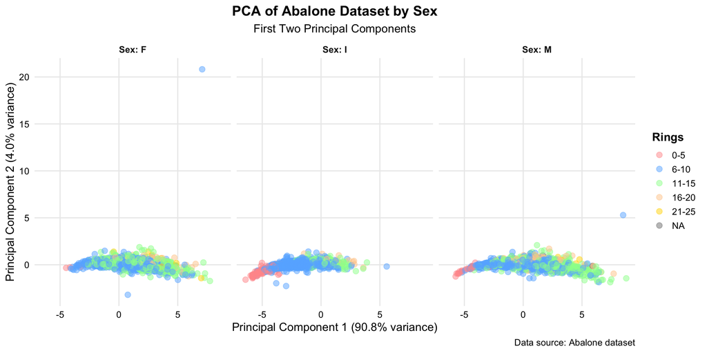

```r
# Load required library for plotting
library(ggplot2)   # Core plotting library for visualizations

# Perform PCA on selected features with scaling
pca_result <- prcomp(d[features], scale. = TRUE)  # Standardize features for PCA

# Extract first two principal components and create a data frame
pca_data <- data.frame(
  PC1 = pca_result$x[, 1],    # First principal component
  PC2 = pca_result$x[, 2],    # Second principal component
  Rings = as.factor(d$Rings), # Treat Rings as categorical for coloring
  Sex = d$Sex                 # Sex for faceting
)

# Create a scatter plot of PCA results, faceted by Sex
ggplot(data = pca_data, aes(x = PC1, y = PC2, color = Rings)) +
  # Add scatter points with transparency and size
  geom_point(alpha = 0.5,              # Transparency to handle overlapping points
             size = 3) +               # Larger points for visibility
  # Facet by Sex, with 3 columns
  facet_wrap(~ Sex, ncol = 3,
             labeller = label_both) +  # Include variable name in facet labels
  # Custom color palette for Rings categories
  scale_color_manual(values = c("#FF9999", "#66B3FF", "#99FF99",
                                "#FFCC99", "#FFD700"),
                     name = "Rings") +      # Legend title for clarity
  # Add descriptive title and axis labels
  labs(
    title = "PCA of Abalone Dataset by Sex",
    subtitle = "First Two Principal Components",
    x = sprintf("Principal Component 1 (%.1f%% variance)",
                100 * pca_result$sdev[1]^2 / sum(pca_result$sdev^2)),
    y = sprintf("Principal Component 2 (%.1f%% variance)",
                100 * pca_result$sdev[2]^2 / sum(pca_result$sdev^2)),
    caption = "Data source: Abalone dataset"
  ) +
  # Apply a clean theme with customized text sizes
  theme_minimal(base_size = 14) +      # Increase base font size for readability
  # Customize theme for legend and facet appearance
  theme(
    legend.position = "right",         # Legend on the right
    legend.title = element_text(face = "bold"), # Bold legend title
    plot.title = element_text(hjust = 0.5, face = "bold"), # Centered, bold title
    plot.subtitle = element_text(hjust = 0.5), # Centered subtitle
    strip.text = element_text(face = "bold"),  # Bold facet labels
    axis.text = element_text(color = "black"), # Black axis text for contrast
    panel.grid.minor = element_blank()         # Remove minor grid lines for clarity
  )
```

```r
summary(pca_result)
```

```
## Importance of components:
##                           PC1     PC2     PC3    PC4     PC5     PC6     PC7
## Standard deviation     2.5209 0.52861 0.40908 0.3377 0.25427 0.11282 0.08159
## Proportion of Variance 0.9079 0.03992 0.02391 0.0163 0.00924 0.00182 0.00095
## Cumulative Proportion  0.9079 0.94779 0.97170 0.9880 0.99723 0.99905 1.00000
```

```r
# Get PCA scores
pca_scores <- as.data.frame(pca_result$x)
head(pca_scores)
```

```
##          PC1        PC2          PC3          PC4         PC5          PC6
## 1 -1.7558088 -0.3904854 -0.329888628 -0.069124568  0.06777093 -0.105806955
## 2 -3.3623317 -0.1051404  0.252233753 -0.012194581  0.01982498 -0.006593863
## 3 -0.4822806  0.2520247 -0.443864736 -0.103691957 -0.04180447 -0.045061317
## 4 -1.5088599  0.2075828 -0.000518465  0.004893957 -0.01884609 -0.186448751
## 5 -3.6535684 -0.2727861  0.275002402 -0.009352292  0.03864842 -0.056971390
## 6 -2.5379618 -0.1677131 -0.054757408 -0.116661344 -0.02383350  0.188539690
##            PC7
## 1  0.018578724
## 2 -0.002665924
## 3  0.045162309
## 4 -0.001684389
## 5  0.026233999
## 6 -0.008871539
```

```r
# Extract loadings
pca_loadings <- pca_result$rotation
print(pca_loadings)  # View loadings
```

```
##                      PC1         PC2        PC3          PC4          PC5
## Length         0.3832508  0.03786529 -0.5932799  0.089331673 -0.040512600
## Diameter       0.3835732  0.06532324 -0.5853661  0.008285814 -0.008517628
## Height         0.3481438  0.86683603  0.3148764  0.165564868  0.027110424
## Whole_weight   0.3906735 -0.23327117  0.2308252 -0.052280164  0.110183954
## Shucked_weight 0.3781883 -0.34801069  0.2315678  0.496179039  0.545339050
## Viscera_weight 0.3815134 -0.25290295  0.2702527  0.140972073 -0.809328460
## Shell_weight   0.3789217 -0.05837478  0.1621047 -0.834110000  0.181668556
##                         PC6           PC7
## Length          0.699651086  0.0238929537
## Diameter       -0.711025627 -0.0158868202
## Height          0.009841283 -0.0007077915
## Whole_weight   -0.021653298  0.8510792809
## Shucked_weight -0.011030516 -0.3721942422
## Viscera_weight -0.023996063 -0.2049136954
## Shell_weight    0.060561675 -0.3071190581
```

### **For explanatory data visualization**

# Explanatory data plot

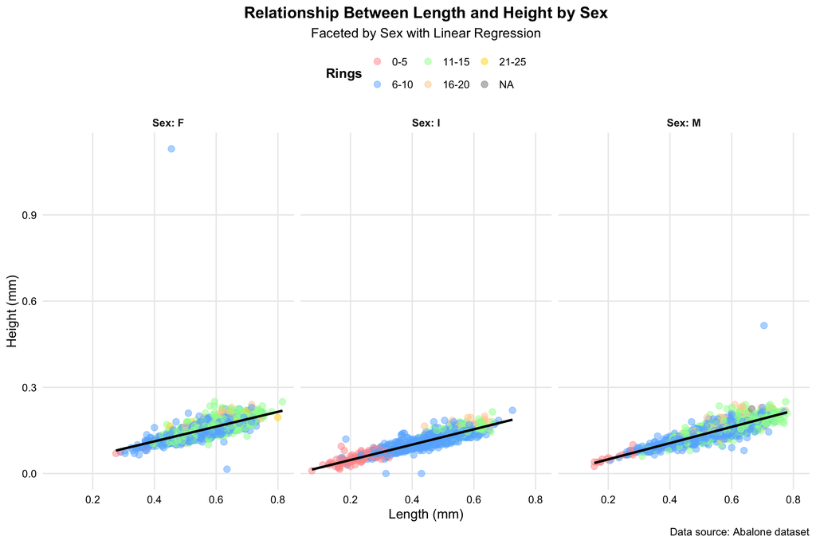

```r
# Load required libraries for plotting
library(ggplot2)   # Core plotting library for creating visualizations
library(GGally)    # For advanced visualizations like pairs plots (optional for this plot)
library(ggforce)   # For ggplot2 extensions (optional unless using specific features)

# Create a scatter plot with regression lines, faceted by Sex
ggplot(data = d, aes(x = Length, y = Height)) +
  # Scatter points colored by Rings, with transparency and size
  geom_point(aes(colour = as.factor(Rings)),  # Treat Rings as categorical
             alpha = 0.5,                     # Transparency to handle overlapping points
             size = 3) +                      # Larger points for visibility in large plot
  # Linear regression line without confidence interval
  geom_smooth(method = "lm",
              se = FALSE,                     # No confidence interval band
              color = "black",                # Black line for contrast
              linewidth = 1.2) +              # Slightly thicker line for clarity
  # Custom color palette for Rings categories
  scale_color_manual(values = c("#FF9999", "#66B3FF", "#99FF99",
                                "#FFCC99", "#FFD700"),
                     name = "Rings") +            # Legend title for clarity
  # Facet by Sex, with 3 columns for side-by-side comparison
  facet_wrap(~ Sex, ncol = 3,
             labeller = label_both) +        # Include variable name in facet labels
  # Add descriptive title and axis labels
  labs(title = "Relationship Between Length and Height by Sex",
       subtitle = "Faceted by Sex with Linear Regression",
       x = "Length (mm)",
       y = "Height (mm)",
       caption = "Data source: Abalone dataset") +
  # Apply a clean theme with customized text sizes
  theme_minimal(base_size = 14) +               # Increase base font size for readability
  # Customize theme for legend and facet appearance
  theme(
    legend.position = "top",                    # Legend at top for accessibility
    legend.title = element_text(face = "bold"), # Bold legend title
    plot.title = element_text(hjust = 0.5, face = "bold"), # Centered, bold title
    plot.subtitle = element_text(hjust = 0.5),  # Centered subtitle
    strip.text = element_text(face = "bold"),   # Bold facet labels
    axis.text = element_text(color = "black"),  # Black axis text for contrast
    panel.grid.minor = element_blank()          # Remove minor grid lines for clarity
  )
```

# plotly intergration

```r
# Load required libraries
library(plotly)       # For interactive plotting
library(dplyr)        # For data manipulation
library(RColorBrewer) # For color palette (Paired)

# =============================================
# DATA PREPARATION
# =============================================

# Split dataset by Sex (F=Female, M=Male, I=Infant)
# Assumes 'd' contains columns: Length, Height, Sex, Rings, Rings_numeric
d_split <- split(d, d$Sex)

# Fit linear regression models (Height ~ Length) for each sex group
# and add predicted values for regression lines
d_with_preds <- lapply(d_split, function(subset) {
  model <- lm(Height ~ Length, data = subset)  # Fit linear regression
  subset$predicted <- predict(model)           # Add predicted Height values
  subset
}) %>% bind_rows()  # Combine subsets into a single dataframe

# =============================================
# VISUALIZATION SETUP
# =============================================

# Define a distinct color palette for Sex categories
# Use RColorBrewer 'Paired' palette (colors 1, 3, 5 for contrast)
sex_colors <- brewer.pal(3, "Paired")[c(1, 3, 5)]
names(sex_colors) <- c("F", "M", "I")  # Assign colors to Sex levels

# =============================================
# MAIN SCATTER PLOT WITH REGRESSION LINES
# =============================================

# Initialize scatter plot with markers
fig_scatter <- plot_ly(data = d_with_preds, type = 'scatter', mode = 'markers') %>%
  # Add scatter points for each data point
  add_markers(
    x = ~Length,          # X-axis: Length
    y = ~Height,          # Y-axis: Height
    color = ~Rings_numeric, # Color by continuous Rings (gradient)
    colors = "Viridis",   # Use Viridis for scientific, perceptually uniform scale
    symbol = ~Sex,        # Different shapes for Sex categories
    symbols = c('circle', 'square', 'diamond'),  # Shapes for F, M, I
    marker = list(
      line = list(color = ~Sex, colors = sex_colors, width = 1), # Outline by Sex
      size = 6           # Smaller marker size for cleaner look
    ),
    # Custom hover text for interactivity
    text = ~paste("Length:", round(Length, 2), "mm",
                  "<br>Height:", round(Height, 2), "mm",
                  "<br>Rings:", Rings,
                  "<br>Sex:", recode(Sex, F = "Female", M = "Male", I = "Infant")),
    hoverinfo = 'text',  # Display custom hover text
    showlegend = TRUE,   # Include in legend
    legendgroup = ~Sex,  # Group by Sex for legend consistency
    name = ~recode(Sex, F = "Female", M = "Male", I = "Infant")  # Friendly legend names
  ) %>%
  # Add regression lines for each Sex group
  add_lines(
    x = ~Length,
    y = ~predicted,
    line = list(color = ~Sex, colors = sex_colors, width = 2), # Thinner lines
    showlegend = FALSE,   # Avoid duplicating legend entries
    legendgroup = ~Sex,   # Match with marker groups
    name = ~recode(Sex, F = "Female", M = "Male", I = "Infant")
  ) %>%
  # Configure axis labels
  layout(
    xaxis = list(title = "Length (mm)", zeroline = FALSE, gridcolor = "lightgrey"),
    yaxis = list(title = "Height (mm)", zeroline = FALSE, gridcolor = "lightgrey")
  )

# =============================================
# MARGINAL HISTOGRAMS
# =============================================

# Top histogram (Length distribution by Sex)
fig_hist_x <- plot_ly() %>%
  # Female Length distribution
  add_histogram(
    data = d_with_preds %>% filter(Sex == "F"),
    x = ~Length,
    marker = list(color = sex_colors["F"]),
    opacity = 0.6,     # Slightly more transparent for clarity
    showlegend = FALSE,
    legendgroup = "Female",
    name = "Female"
  ) %>%
  # Male Length distribution
  add_histogram(
    data = d_with_preds %>% filter(Sex == "M"),
    x = ~Length,
    marker = list(color = sex_colors["M"]),
    opacity = 0.6,
    showlegend = FALSE,
    legendgroup = "Male",
    name = "Male"
  ) %>%
  # Infant Length distribution
  add_histogram(
    data = d_with_preds %>% filter(Sex == "I"),
    x = ~Length,
    marker = list(color = sex_colors["I"]),
    opacity = 0.6,
    showlegend = FALSE,
    legendgroup = "Infant",
    name = "Infant"
  ) %>%
  # Configure histogram layout (minimal axes)
  layout(
    xaxis = list(showticklabels = FALSE, title = "", showline = FALSE, zeroline = FALSE),
    yaxis = list(showticklabels = FALSE, title = "", showline = FALSE, zeroline = FALSE),
    barmode = "overlay"  # Overlay histograms for comparison
  )

# Right histogram (Height distribution by Sex)
fig_hist_y <- plot_ly() %>%
  # Female Height distribution
  add_histogram(
    data = d_with_preds %>% filter(Sex == "F"),
    y = ~Height,
    marker = list(color = sex_colors["F"]),
    opacity = 0.6,
    showlegend = FALSE,
    legendgroup = "Female",
    name = "Female"
  ) %>%
  # Male Height distribution
  add_histogram(
    data = d_with_preds %>% filter(Sex == "M"),
    y = ~Height,
    marker = list(color = sex_colors["M"]),
    opacity = 0.6,
    showlegend = FALSE,
    legendgroup = "Male",
    name = "Male"
  ) %>%
  # Infant Height distribution
  add_histogram(
    data = d_with_preds %>% filter(Sex == "I"),
    y = ~Height,
    marker = list(color = sex_colors["I"]),
    opacity = 0.6,
    showlegend = FALSE,
    legendgroup = "Infant",
    name = "Infant"
  ) %>%
  # Configure histogram layout (minimal axes)
  layout(
    yaxis = list(showticklabels = FALSE, title = "", showline = FALSE, zeroline = FALSE),
    xaxis = list(showticklabels = FALSE, title = "", showline = FALSE, zeroline = FALSE),
    barmode = "overlay"  # Overlay histograms for comparison
  )

# =============================================
# COMBINE PLOTS USING SUBPLOT
# =============================================

# Combine scatter plot and marginal histograms
fig <- subplot(
  fig_hist_x, plotly_empty(),  # Top row: Length histogram, empty space
  fig_scatter, fig_hist_y,     # Bottom row: scatter plot, Height histogram
  nrows = 2,
  widths = c(0.8, 0.2),       # 80% scatter, 20% right histogram
  heights = c(0.2, 0.8),      # 20% top histogram, 80% scatter
  shareX = TRUE,              # Share x-axis with scatter plot
  shareY = TRUE               # Share y-axis with scatter plot
) %>%
  # Final layout adjustments for scientific aesthetic
  layout(
    title = list(
      text = "Abalone Length vs. Height by Sex and Rings",
      font = list(size = 14, family = "Arial", color = "black"),
      x = 0.5, xanchor = "center"  # Centered title
    ),
    legend = list(
      title = list(text = "Sex", font = list(size = 12, family = "Arial")),
      x = 0.85, y = 0.98,        # Position legend top-right
      xanchor = "right", yanchor = "top",
      font = list(size = 10, family = "Arial"),
      bgcolor = "rgba(255, 255, 255, 0.9)", # Slightly opaque background
      bordercolor = "black",
      borderwidth = 1
    ),
    showlegend = TRUE,
    plot_bgcolor = "white",      # White plot background
    paper_bgcolor = "white"      # White canvas background
  )
# Display the final interactive plot
fig
```

[interactive chart not shown]

# What is the Plotly integration differ into static integration?

1. It allows for the user to hover over points to see more information, zoom in and out, and pan around the plot. This is particularly useful for exploring large datasets or for presentations where you want to highlight specific points or trends.
2. It allows for the presentors to highlight some specific points or trends in the data.
3. It allows for the user to download the plot as a PNG image, which is not possible with static plots. This can be useful for sharing or including in reports.

# Discussion

The analysis of the Abalone dataset reveals several interesting insights. The pairplot shows the relationships between different features, with some features exhibiting strong correlations. The box and sina plots provide a clear visualization of the distribution of features across different Rings categories, highlighting the differences in feature values.

The pca analysis and the box and sina plot show that the Length and the diameter has are very- highly correlated and nearly identical. But height plays also a important factor to the age of the ablone. One of the interesting part is that the boxplot is showing those parameters has a logrametic relationship to the result.